# Higher Prelim Topic Revision - Web Version

## 7 Graph Transformations

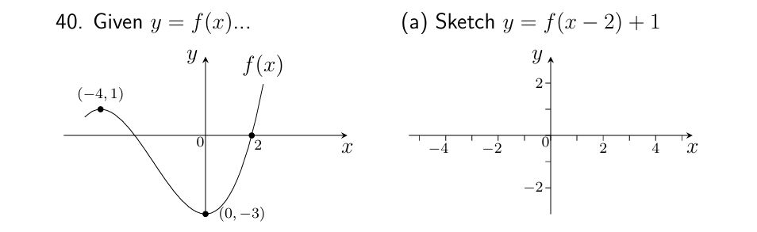

Make a list of all coordinates on the *original* graph (here there are 3).

Everything *outside* the $(x)$ bracket affects $y$-coordinates. These transformations are usually seen as *intuitive*.

Everything *inside* the $(x)$ bracket affects $x$-coordinates. These transformations are usually seen as *counterintuitive*.

Make sure your final graph has *all* the transformed *images* of the original coordinates clearly shown.

See full solution below for the graph and coordinates.

*For more practice, try:* **[Zeta Higher Textbook](https://ebooks.zetapress.co.uk/yyrtww), Page 86, Exercise 5.5, Questions 1(a), 1(b) and 1(c)**

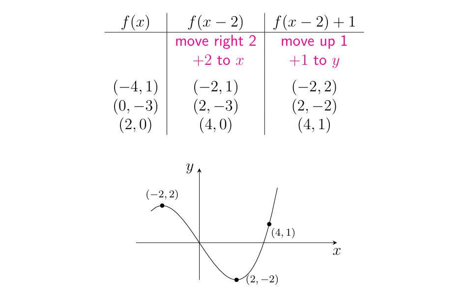

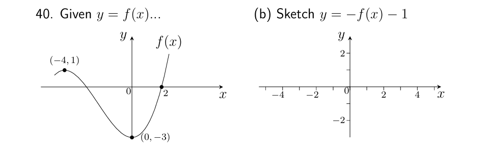

Remember to apply the two transformations following the rules of operation: $\times(-1)$ *then* $-1$

As well as changing the coordinates, think about how the transformations will change the *shape* and *position* of the graph. Here, $-f(x)$ will *flip the graph upside down*.

See full solution below for the graph and coordinates.

*For more practice, try:* **[Zeta Higher Textbook](https://ebooks.zetapress.co.uk/yyrtww), Page 86, Exercise 5.5, Questions 1(d), 1(e) an 1(f)**

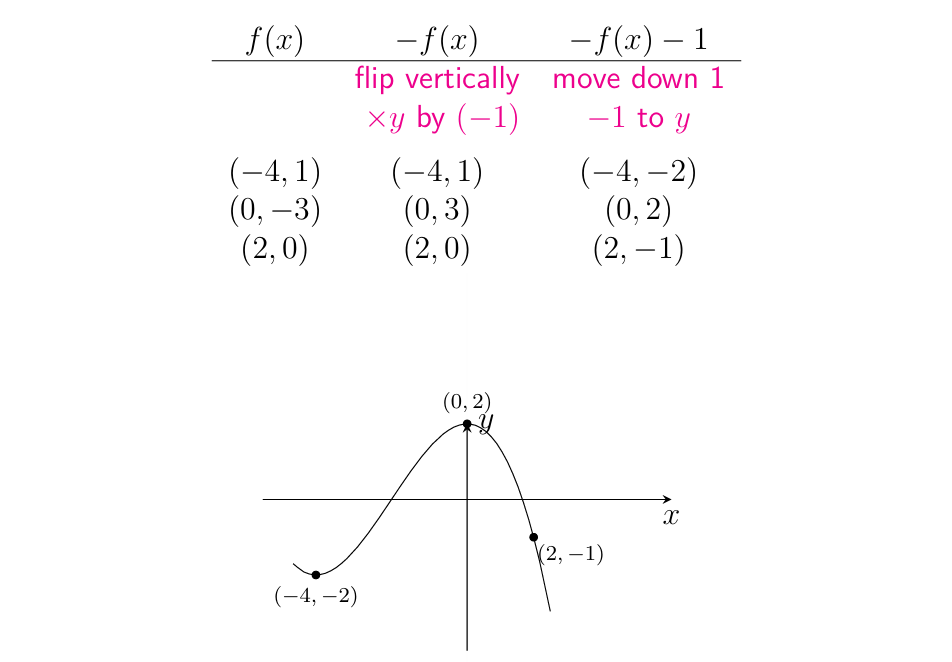

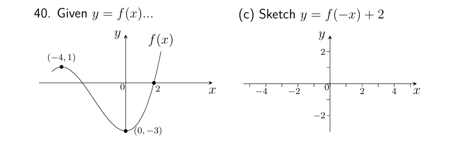

If $-f(x)$ is a *vertical* flip, what is $f(-x)$?

See full solution below for the graph and coordinates.

*For more practice, try:* **[Zeta Higher Textbook](https://ebooks.zetapress.co.uk/yyrtww), Page 87, Exercise 5.5, Questions 2(g), 2(h) and 2(i)**

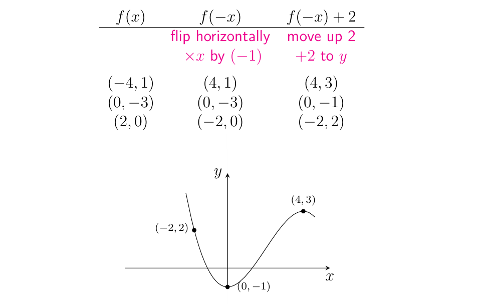

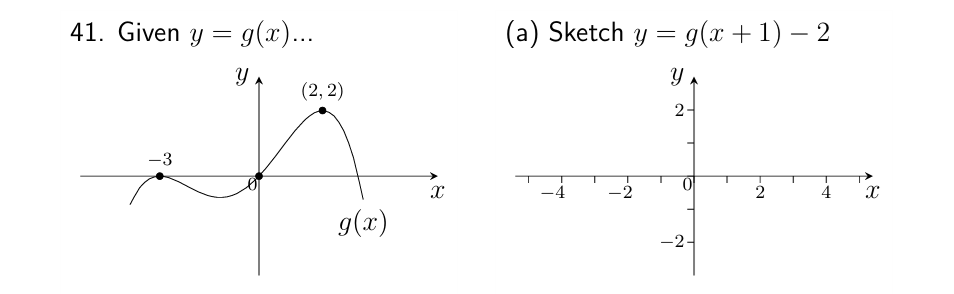

Don't ignore the coordinate of $(0,0)$ on the original graph.

See full solution below for the graph and coordinates.

*For more practice, try:* **[Zeta Higher Textbook](https://ebooks.zetapress.co.uk/yyrtww), Page 88, Exercise 5.5, Questions 3(a), 3(b) and 3(c)**

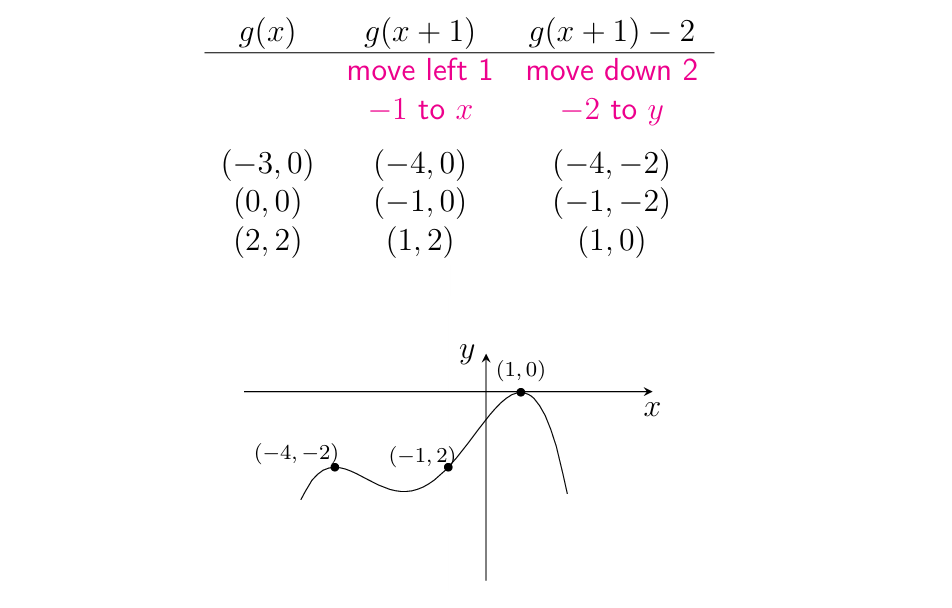

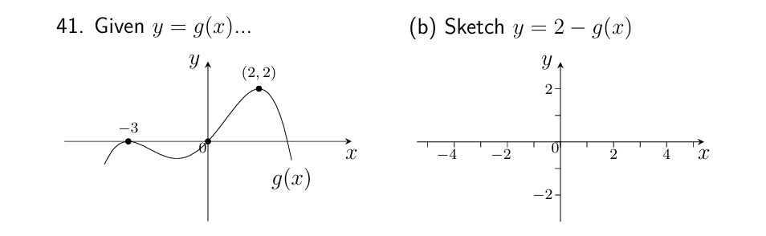

$2-g(x)$ can be rewritten as $-g(x)+2$.

See full solution below for the graph and coordinates.

*For more practice, try:* **[Zeta Higher Textbook](https://ebooks.zetapress.co.uk/yyrtww), Page 88, Exercise 5.5, Questions 3(d), 3(e) and 3(f)**

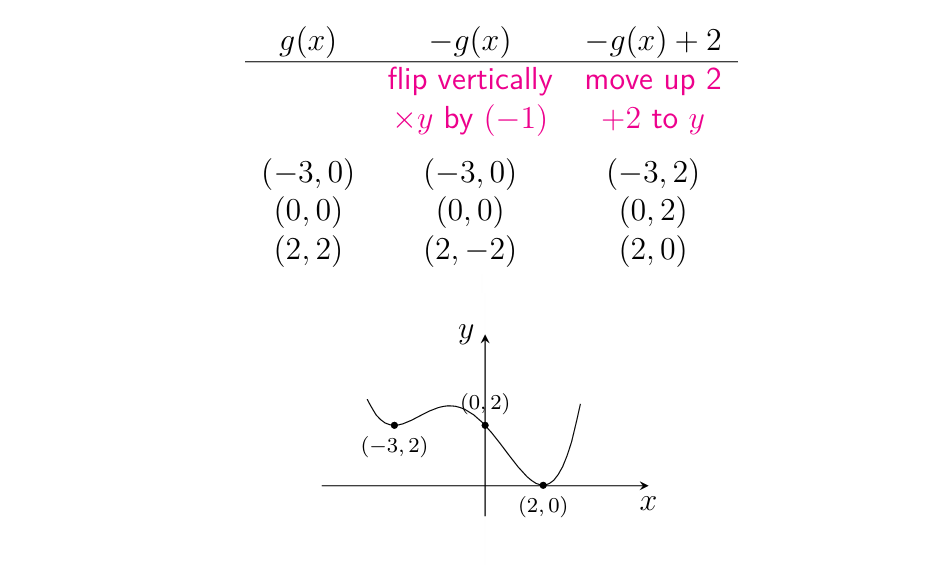

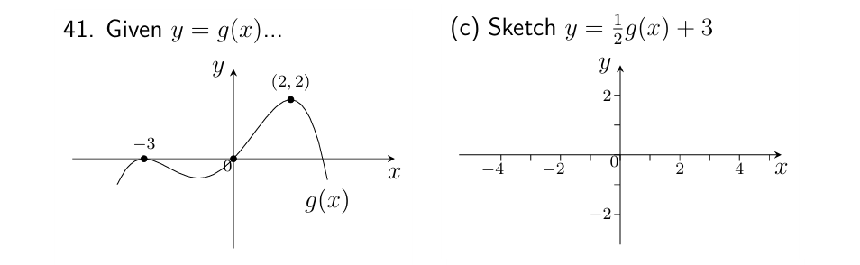

$\frac{1}{2}g(x)$ is a *vertical compression* by factor 2.

See full solution below for the graph and coordinates.

*For more practice, try:* **[Zeta Higher Textbook](https://ebooks.zetapress.co.uk/yyrtww), Page 88, Exercise 5.5, Questions 3(g), 3(h) and 3(i)**

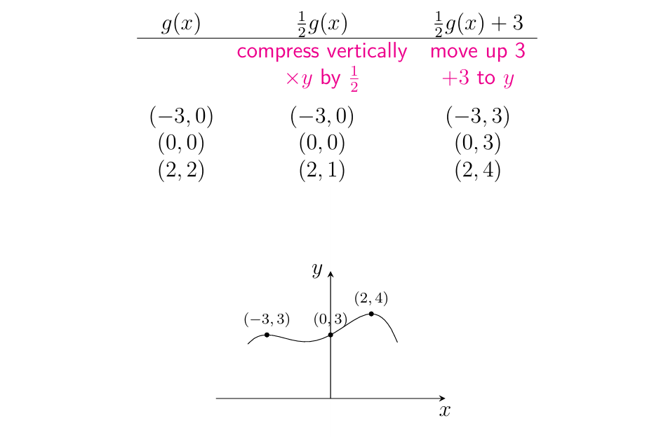

## 8 Vectors

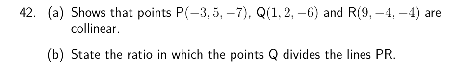

Find the components of vectors $\overrightarrow{PQ}$ and $\overrightarrow{QR}$.

Make sure your collinearity statement is *carefully and fully worded*.

Draw a *sketch* to make (b) easier to see.

1. $2\overrightarrow{PQ}=\overrightarrow{QR}$, valid statement *(see solution)*.
2. $1:2$

*For more practice, try:* **[Zeta Higher Textbook](https://ebooks.zetapress.co.uk/yyrtww), Page 215, Exercise 14.6, Questions 1(a), 1(b) and 1(c)**

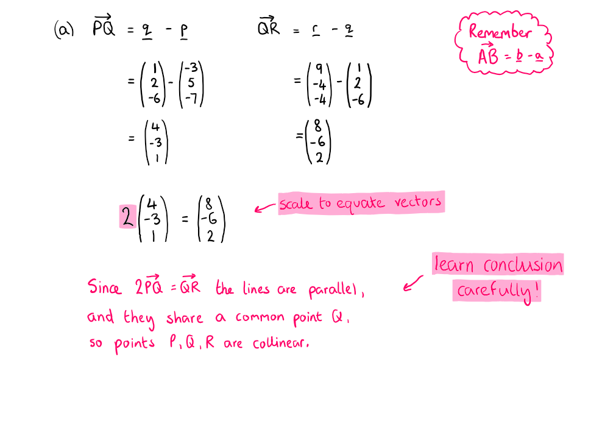

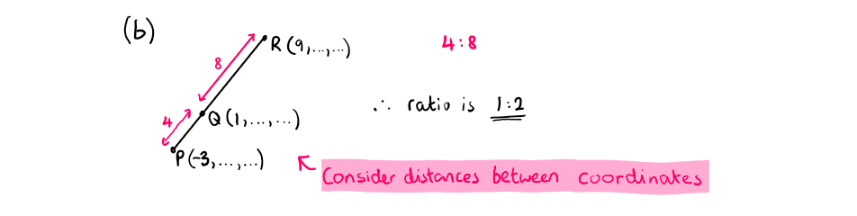

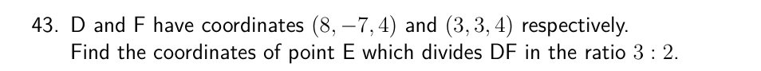

Check which method your teacher taught you to use. One option is the *section formula*.

E$(5,-1,4)$

*For more practice, try:* **[Zeta Higher Textbook](https://ebooks.zetapress.co.uk/yyrtww), Page 216, Exercise 14.7, Questions 1(a), 1(b) and 1(c)**

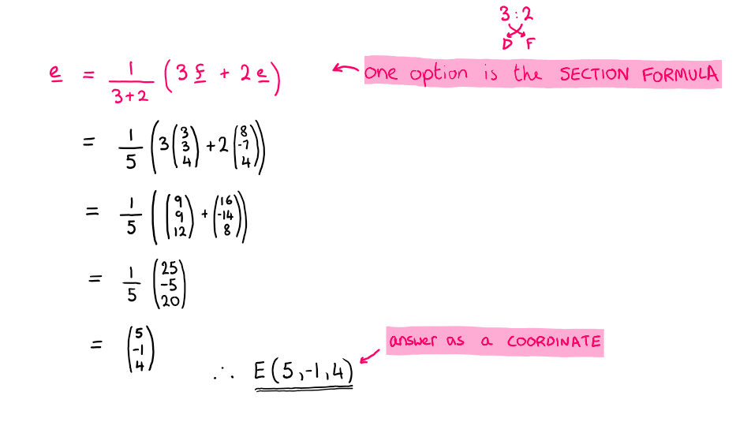

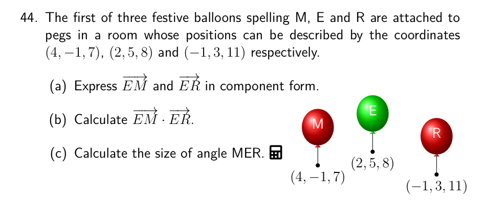

1. Use $\overrightarrow{AB}=\mathbf{b}-\mathbf{a}$
2. The formula sheet reminds you how to do this.
3. Use the formula $\mathbf{a}\cdot\mathbf{b}=|\mathbf{a}||\mathbf{b}|\cos{\theta}$, rearranged and in terms of $\overrightarrow{EM}$ and $\overrightarrow{ER}$.
1. $\overrightarrow{EM}$=

   $$\begin{pmatrix}
   \phantom{-}2\\
   -6\\
   -1
   \end{pmatrix}$$

   and $\overrightarrow{ER}=$

   $$\begin{pmatrix}
   -3\\
   -2\\
   \phantom{-}3
   \end{pmatrix}$$
2. 3
3. $84.3^{\circ}$

*For more practice, try:* **[Zeta Higher Textbook](https://ebooks.zetapress.co.uk/yyrtww), Page 222, Exercise 14.10, Questions 3(b), 4(a) and 5(a)**

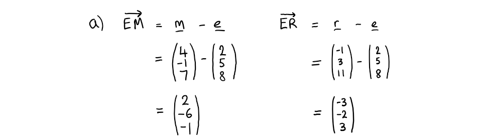

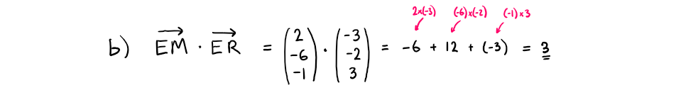

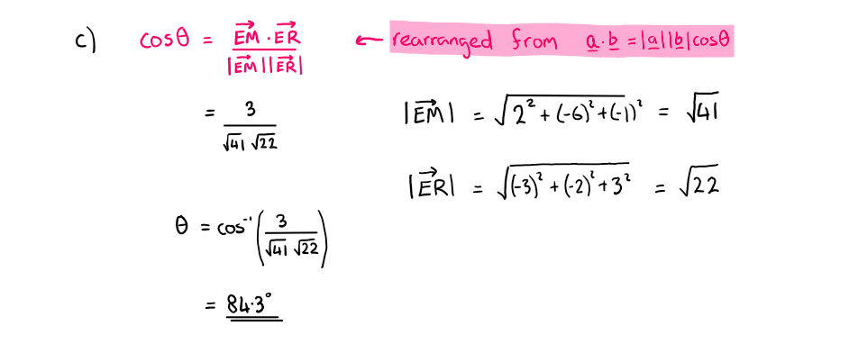

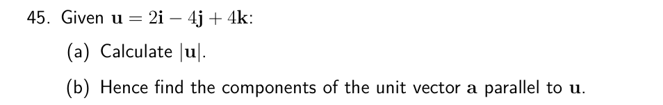

If a vector has a magnitude of $k$, multiplying that vector by $\frac{1}{k}$ will create a parallel vector with a length of $1$ (a unit vector).

$\begin{pmatrix} \frac{1}{3}\\ -\frac{2}{3}\\ \frac{2}{3} \end{pmatrix}$

*For more practice, try:* **[Zeta Higher Textbook](https://ebooks.zetapress.co.uk/yyrtww), Page 213, Exercise 14.4, Questions 1, 2 and 3**

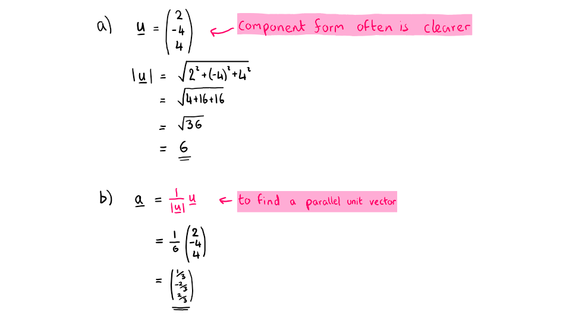

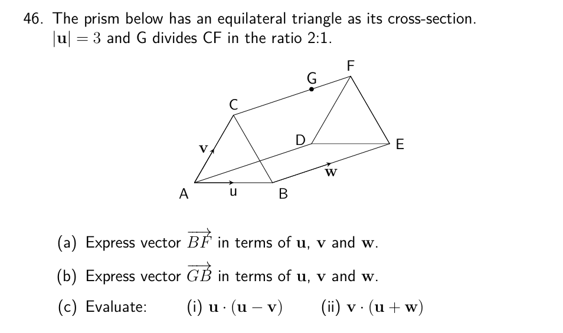

*For more practice, try:* **[Zeta Higher Textbook](https://ebooks.zetapress.co.uk/yyrtww), Page 226, Exercise 14.12B, Questions 3, 4 and 6**

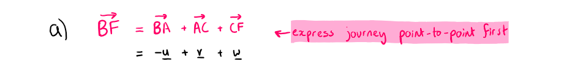

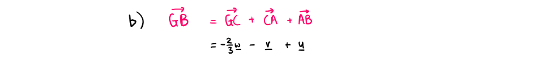

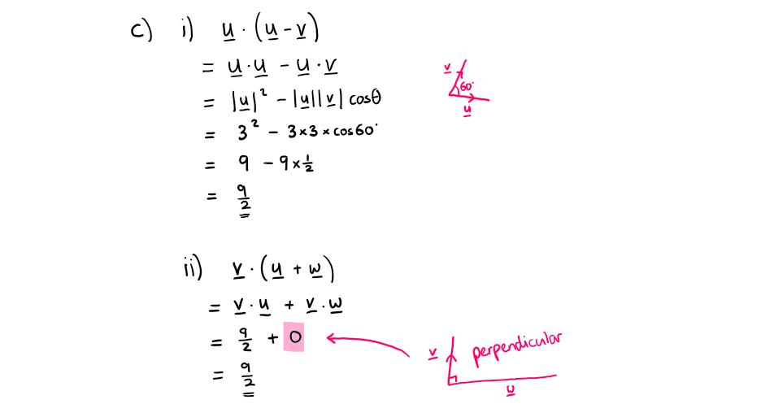